# Practical Machine Learning

Jerry Jasinski

08/20/2015

# Background

Using devices such as Jawbone Up, Nike FuelBand, and Fitbit it is now possible to collect a large amount of data about personal activity relatively inexpensively. These type of devices are part of the quantified self movement – a group of enthusiasts who take measurements about themselves regularly to improve their health, to find patterns in their behavior, or because they are tech geeks. One thing that people regularly do is quantify how much of a particular activity they do, but they rarely quantify how well they do it. In this project, your goal will be to use data from accelerometers on the belt, forearm, arm, and dumbell of 6 participants. They were asked to perform barbell lifts correctly and incorrectly in 5 different ways. More information is available from the website here: http://groupware.les.inf.puc-rio.br/har (see the section on the Weight Lifting Exercise Dataset).

## Data

The training data for this project are available here:

https://d396qusza40orc.cloudfront.net/predmachlearn/pml-training.csv

The test data are available here:

https://d396qusza40orc.cloudfront.net/predmachlearn/pml-testing.csv

## Libraries Needed

```r
library(caret)
library(rpart)
library(rattle)
library(randomForest)
```

### Reading and Cleaning the data from the CSV files.

```r
trainRaw <- read.csv(url("https://d396qusza40orc.cloudfront.net/predmachlearn/pml-training.csv"), na.strings=c("NA", "#DIV/0!", ""))

testRaw <- read.csv(url("https://d396qusza40orc.cloudfront.net/predmachlearn/pml-testing.csv"), na.strings=c("NA", "#DIV/0!", ""))

# Remove columns with NA/bad values.
trainClean1 <- trainRaw[, colSums(is.na(testRaw)) == 0]
testClean1 <- testRaw[, colSums(is.na(testRaw)) == 0]

# Store the classe column until after datasets are cleaned.
trainAnswers <- trainRaw$classe

# Remove columns that contain the strings "timestamp" or "window"
unsedCols <- grepl("^X|timestamp|window", names(trainClean1))
trainClean <- trainClean1[, !unsedCols]
testClean <- testClean1[, !unsedCols]

# Retain columns that are numeric.
trainCleanFinal <- trainClean[, sapply(trainClean, is.numeric)]
testCleanFinal <- testClean[, sapply(testClean, is.numeric)]

# Put the trainAnswers column back to the cleaned training data.
trainClean <- trainCleanFinal
trainClean$classe <- trainAnswers

testClean <- testCleanFinal

dim(trainClean)
```

```
## [1] 19622    53
```

```r
dim(testClean)
```

```
## [1] 20 53
```

```r
set.seed(13579)
inTrainingSet <- createDataPartition(trainClean$classe, p=0.70, list=FALSE)
trainData <- trainClean[inTrainingSet, ]
testData <- trainClean[-inTrainingSet, ]
dim(trainData)
```

```
## [1] 13737    53
```

```r
dim(testData)
```

```
## [1] 5885   53
```

### We will try Decision Trees First for our prediction Model

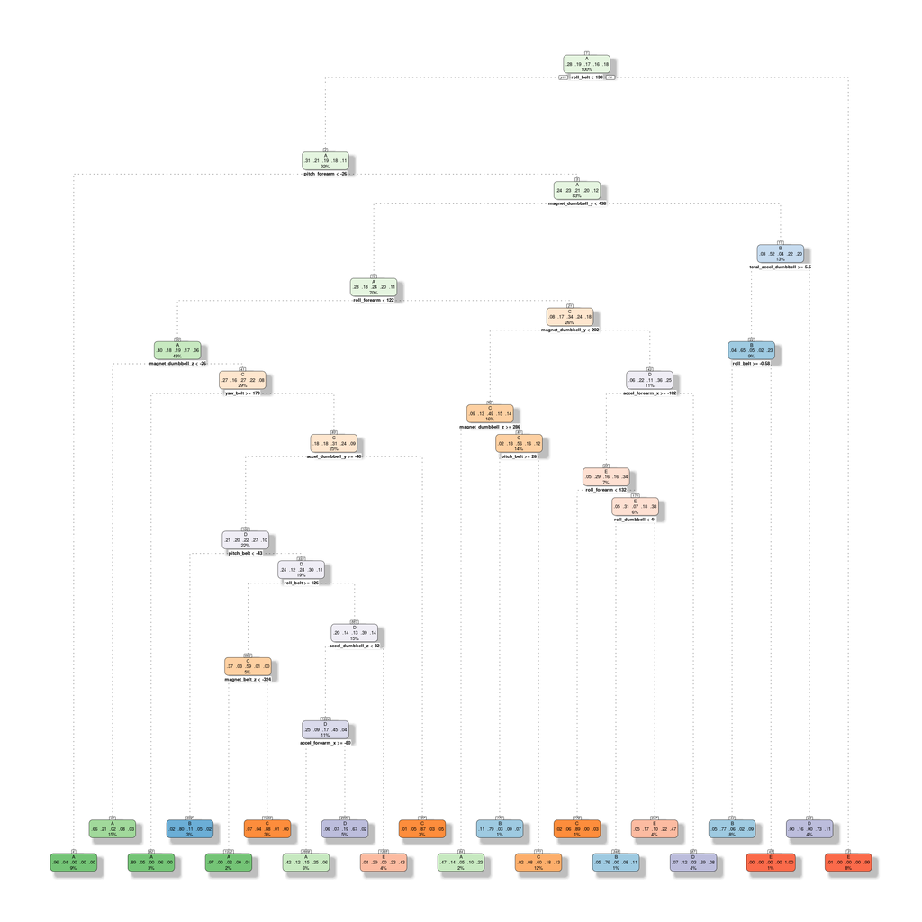

```r
modelDT <- rpart(classe ~ ., data=trainData, method='class')

## View the Decision Tree

fancyRpartPlot(modelDT, sub = '')
```

```r
# Predict and test
dtPredictions <- predict(modelDT, testData, type="class")

confusionMatrix(dtPredictions, testData$classe)
```

```
## Confusion Matrix and Statistics
##
##           Reference
## Prediction    A    B    C    D    E
##          A 1543  278   86  176   69
##          B   43  565   53   22   46
##          C   39   87  799  130  120
##          D   28   79   65  529   45
##          E   21  130   23  107  802
##
## Overall Statistics
##
##                Accuracy : 0.7201
##                  95% CI : (0.7085, 0.7316)
##     No Information Rate : 0.2845
##     P-Value [Acc > NIR] : < 2.2e-16
##
##                   Kappa : 0.6424
##  Mcnemar's Test P-Value : < 2.2e-16
##
## Statistics by Class:
##
##                      Class: A Class: B Class: C Class: D Class: E
## Sensitivity            0.9217  0.49605   0.7788  0.54876   0.7412
## Specificity            0.8554  0.96544   0.9226  0.95590   0.9415
## Pos Pred Value         0.7170  0.77503   0.6800  0.70912   0.7405
## Neg Pred Value         0.9649  0.88867   0.9518  0.91535   0.9417
## Prevalence             0.2845  0.19354   0.1743  0.16381   0.1839
## Detection Rate         0.2622  0.09601   0.1358  0.08989   0.1363
## Detection Prevalence   0.3657  0.12387   0.1997  0.12676   0.1840
## Balanced Accuracy      0.8886  0.73075   0.8507  0.75233   0.8414
```

The decision Tree had only a 72% acccuracy. I would expect ~ 28% out of sample error rate

```r
accuracy <- postResample(dtPredictions, testData$classe)
accuracy
```

```
##  Accuracy     Kappa
## 0.7201359 0.6423917
```

```r
outOfSampleError <- 1 - as.numeric(confusionMatrix(testData$classe, dtPredictions)$overall[1])
outOfSampleError
```

```
## [1] 0.2798641
```

### Let’s try the Random Forect and see if we can get better results.

```r
modelRF <- randomForest(classe ~ ., data=trainData)

# Predict and test
rfPredictions <- predict(modelRF, testData, type="class")

confusionMatrix(rfPredictions, testData$classe)
```

```
## Confusion Matrix and Statistics
##
##           Reference
## Prediction    A    B    C    D    E
##          A 1673    9    0    0    0
##          B    0 1125    5    0    0
##          C    0    5 1019    7    1
##          D    0    0    2  957    2
##          E    1    0    0    0 1079
##
## Overall Statistics
##
##                Accuracy : 0.9946
##                  95% CI : (0.9923, 0.9963)
##     No Information Rate : 0.2845
##     P-Value [Acc > NIR] : < 2.2e-16
##
##                   Kappa : 0.9931
##  Mcnemar's Test P-Value : NA
##
## Statistics by Class:
##
##                      Class: A Class: B Class: C Class: D Class: E
## Sensitivity            0.9994   0.9877   0.9932   0.9927   0.9972
## Specificity            0.9979   0.9989   0.9973   0.9992   0.9998
## Pos Pred Value         0.9946   0.9956   0.9874   0.9958   0.9991
## Neg Pred Value         0.9998   0.9971   0.9986   0.9986   0.9994
## Prevalence             0.2845   0.1935   0.1743   0.1638   0.1839
## Detection Rate         0.2843   0.1912   0.1732   0.1626   0.1833
## Detection Prevalence   0.2858   0.1920   0.1754   0.1633   0.1835
## Balanced Accuracy      0.9986   0.9933   0.9953   0.9960   0.9985
```

The Random Forest’s accuracy of better than 99% will be used for the submitted predictions.

### Generating files for submission using the Random Forest prediction model

```r
result <- predict(modelRF, testClean)

path <- "./testPredictions"

pml_write_files <- function(x){
      n = length(x)
      for(i in 1:n){
            filename = paste0("problem_id_",i,".txt")
            write.table(x[i], file=file.path(path, filename), quote=FALSE, row.names=FALSE, col.names=FALSE)
            }
}

pml_write_files(result)
```